# pres_SlidingMode slides

## Sliding variables and sliding mode control (SISO only)

### Vivek Yadav, PhD

#### MEC 560: Advanced Control Systems

### Motivation

- Transform an original n-order nonlinear control system into a first order sytem.
- Simplify the original dynamics so control design becomes easier.
- Force the system dynamics onto a manifold such that the resulting dynamics becomes simple.

#### Motivation,

Given a n-order system, \( X^{(n)} = f(X) + g(X) u \), transform it into a first order dynamics using a variable \( s \). \( s \) satisfies the following 2 properties,

1. \( \dot{x} \) contains \( u \).
2. If \( s \rightarrow 0 \) then \( x \rightarrow 0 \).

Choose control such that \( s = 0 \) once the states reach sliding manifold.

#### Example Sliding mode:

For \( n = 2 \), say a system is given by,

$$ \ddot{x} = f(x) + g(x)u $$

We wish to drive \( x \rightarrow x_d \) and \( \dot{x} \rightarrow \dot{x}_d \). Choose \( s \) such that

1. \( \dot{x} \) contains \( u \).
2. If \( s \rightarrow 0 \) then \( x \rightarrow 0 \).

Choose

$$ s = \lambda (x - x_d ) + ( \dot{x} - \dot{x}_d)=\lambda e+ \dot{e}$$

For a general \( n \) order system, the sliding variable can be selected as,

$$ s = \left( \frac{d}{dt} + \lambda \right)^{n-1} e $$

Note in the expressions above, \( e \) can be considered as a filter response to input \( s \), therefore if \( s \rightarrow 0 \), then \( x \rightarrow 0 \).

### Geometric interpretation

- For 2-dimension case, \( s = \dot{e} + \lambda e\) represents a line with slope of \( -\lambda \) in the phasephot, and the line contrains origin.
- In general, if we plot \( x \) vs \( \dot{x}\), then the line will pass through \( x_d \) and \( \dot{x}_d \) and will have the slope of \( -\lambda\).

For a general n-dimension system, \( s= 0\) represents a hyperplane in the \( n-1 \) that passes through the origin (or desired point) depending on the variable representation.

[figure not shown]

### Boundedness of states

Say we are able to bound the sliding variables \( s \) such that \( |s|\leq \phi \) after some transient dynamics. We are interested in the bounds on the error \( e \) when \(|s| \leq \phi \). We will consider a second order system first, in this case, the sliding variable is given by,

$$ s = \dot{e} + \lambda e $$

$$ \lambda exp(\lambda t) e + exp(\lambda t) \frac{de}{dt} = exp(\lambda t) s $$$$ \frac{d(exp(\lambda t)e)}{dt} = exp(\lambda t) s $$$$ d(exp(\lambda t)e) = exp(\lambda t) s dt $$

Integrating between \( t_f \) and \( 0 \) gives,

$$e(T) = e(0) exp(-\lambda T) + \int_0^T exp(-\lambda (T-t)) s dt $$

We will study the boundedness of \( e(T) \) as \( T \rightarrow \infty \). As \( T \) becomes large, \( exp(-\lambda T) \rightarrow 0 \), for \( \lambda >0 \). Therefore, the first term is bounded, we will investigate the second term only. As \(|s| \leq \phi \),

$$ \int_0^T exp(-\lambda (T-t)) s dt \leq \phi \int_0^T exp(-\lambda (T-t)) dt$$

Integrating the term on the right gives,

$$ \frac{\phi}{\lambda} (1-exp(-\lambda T)) \leq \frac{\phi}{\lambda} $$

Therefore, the error \( e \) is bounded by \( \phi/\lambda \). We can show that for a n-dimension system, the error is bounded by,

$$ e \leq \frac{\phi}{\lambda^{n-1}} $$

Therefore, if we are able design a control that ensures \( s \leq \phi \) we are assued due to sliding variable that \( e \leq \frac{\phi}{\lambda^{n-1}} \).

### Sliding mode control:

Say we are intersted in controlling a second order system given by,

$$ \ddot{x} = f(x,\dot{x}) + g(x,\dot{x}) u $$

Once we design the sliding variable, we can design control based to drive \( s \rightarrow 0 \). Define a Lyapunov function \( L \) as,

$$ L = \frac{1}{2}s^2 $$

Taking derivative gives,

$$ \dot{L} = s \dot{s} $$

Therefore, if we choose \( u \) such that \( s \dot{s} < 0 \) always, then the \( s \rightarrow 0 \). The derivative of Lyapunov can we written as,

$$ \dot{L} = s ( \ddot{x} + \lambda \dot{x}) = s ( f(x,\dot{x}) + g(x,\dot{x}) u + \lambda \dot{x})$$

choosing \( u = - g(x,\dot{x})^{-1} (f(x,\dot{x}) + \lambda \dot{x} + \eta sign(s))\)

$$ \dot{L} = - \eta |s| $$

- The resultant control is chosen as \( \eta sign(s) \) instead of \( -\eta s \) to have a constant 'velocity' towards the sliding surface.
- This ensures that we reach the sliding surface in a finite time and not asymptotically.

### Example 1 :

Consider the example of a system given by,

$$ \ddot{x} + 1.5 \dot{x}^2cos(3x) = u $$

with \( 1 \leq a(t) \leq 2 \), we would like to convert this to a first order system. Lets define a sliding variable \( s\),

$$ s = \dot{x} + \lambda x $$

as \( x \) is a first order response to \( s \). \(s \) satisfies,

- \( x \rightarrow 0 \) as \( s \rightarrow 0 \)
- \( \dot{s} \) contains \( u \)

Therefore, \( s \) is a valid choice for sliding variable.

Choose the Lyapunov, \( L \) as

$$ L = \frac{1}{2} s^2 $$

Taking derivative of \( L \) gives,

$$ \dot{L} = s \dot{s} =s ( \ddot{x} + \lambda \dot{x}) = s (u - 1.5 \dot{x}^2cos(3x)) + \lambda x $$

Choosing \( u = 1.5 \dot{x}^2cos(3x)) - \lambda x - \eta sign(s) \). gives,

$$ \dot{L} = - \eta |s|$$

```matlab
clc
close all
clear all

x(:,1) = [1;1];
dt = 0.01;
lambda = 1;
eta = 5;

for i = 2:2000,
    s(i) = x(2,i-1)+lambda*x(1,i-1);
    u(i) = 1.5*x(2,i-1)^2*cos(3*x(1,i-1)) - lambda*x(1,i-1) - eta*sign(s(i));
    x(1,i) = x(1,i-1) + dt*(x(2,i-1));
    x(2,i) = x(2,i-1) + dt*(u(i) - 1.5*cos(3*x(1,i-1)));

end
```

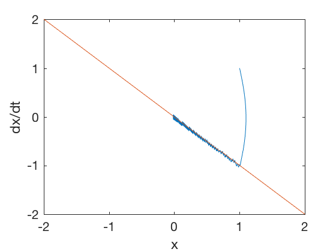

```matlab
plot(x(1,:),x(2,:))
hold on
plot([-2:.01:2],-lambda*[-2:.01:2])
xlabel('x')
ylabel('dx/dt')
```

### Sliding mode control for control under uncertainty:

Conside the second order true system system that is given by

$$ \ddot{x} = f(x,\dot{x}) + g(x,\dot{x}) u $$

and say the approximate system we know is given by,

$$ \ddot{x} = \hat{f}(x,\dot{x}) + g(x,\dot{x}) u $$

such that \( |f - \hat{f}| \leq F \). Sliding mode control lends itself very well to such problems. The technique to design control is similar. We first choose a sliding variable, \( s = \dot{x} + \lambda x \). Similar to process above, we define a Lyapunov,

$$ L = \frac{1}{2} s^2 $$

Taking derivative gives,

$$ \dot{L} = s \dot{s} = s(f(x,\dot{x}) + g(x,\dot{x}) u + \lambda \dot{x}) $$

Now, we do not know \( f(x,\dot{x}) \) accurately, so we can use estimate of \( f \) for designing control instead of the true \( f (x,\dot{x})\). Choosing \( u = - g(x,\dot{x})^{-1} ( \ \hat{f}(x,\dot{x}) +F + \lambda \dot{x} + \eta sign(s) )\) gives,

$$ \dot{L} = s(f(x,\dot{x}) -\hat{f}(x,\dot{x}) -F - \eta sign(s)) $$

As \( |f - \hat{f}| \leq F \),

$$ \dot{L} \leq s( - \eta sign(s)) $$

Therefore, the choice of control \( u = - g(x,\dot{x})^{-1} ( \ \hat{f}(x,\dot{x}) +F + \lambda \dot{x} + \eta sign(s) )\) drives \( s \rightarrow 0 \).

### Example 2:

Consider the example of a system given by,

$$ \ddot{x} + a(t) \dot{x}^2cos(3x) = u $$

with \( 1 \leq a(t) \leq 2 \), we would like to control this sytem so \( x \rightarrow 0 \). As we do not know \( a(t) \) precisely, we choose an estimate as, \( 1.5 \dot{x}^2cos(3x) \). Therefore,

$$ f - \hat{f} = (a(t)-1.5) x^2 cos(3x) \leq .5x^2|cos(3x)|$$

We will now define a sliding variable, \( s \) as,

$$ s = \dot{x} + \lambda x $$$$ L = \frac{1}{2} s^2 $$

Taking derivative of Lyapunov,

$$ \dot{L} = s (\ddot{x} + \lambda \dot{x} )= s((u - a(t) \dot{x}^2cos(3x)) + \lambda x ) $$

As we do not know \( a(t) \) precisely, we can replace it with an estimate, \( 1.5 \dot{x}^2cos(3x) \)

$$ \dot{L} = s( (1.5 - a(t) ) \dot{x}^2cos(3x)- .5x^2|cos(3x)| - \eta sign(s) ) $$$$\dot{L} \leq s( - \eta sign(s) ) \leq \eta |s| $$

```matlab
clc
close all
clear all

x(:,1) = [1;1];
dt = 0.01;
lambda = 1;
eta = 5;

for i = 2:2000,
    s(i) = x(2,i-1)+lambda*x(1,i-1);
    u(i) = 1.5*x(2,i-1)^2*cos(3*x(1,i-1)) - lambda*x(1,i-1) - eta*sign(s(i));
    x(1,i) = x(1,i-1) + dt*(x(2,i-1));
    a = 1+rand;
    x(2,i) = x(2,i-1) + dt*(u(i) - a*cos(3*x(1,i-1)));

end
```

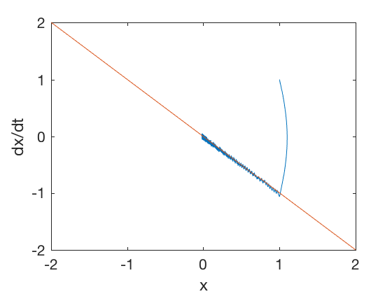

```matlab
plot(x(1,:),x(2,:))
hold on
plot([-2:.01:2],-lambda*[-2:.01:2])
xlabel('x')
ylabel('dx/dt')
```

### Chattering in sliding mode control:

- The sliding mode control is a discountinuous control, because we are making sure we always go towards the sliding surface with constant velocity.
- This can result in chattering, when the control switches quickly around the sliding surface.
- Chattering can be avoided by including a smoother transition across zero, by using a sigmoid (tanh) type of function, however, this results in a scenario where the controller may not drive the sliding variable to zero precisely, but to a neighborhood of zero.

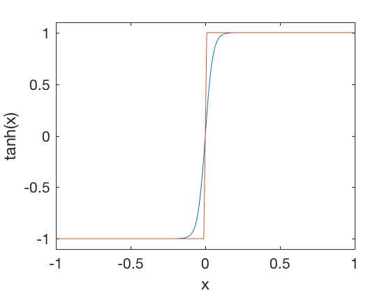

```matlab
x = -1:.01:1;
plot(x,tanh(20*x),x,sign(x))
xlabel('x')
ylabel('tanh(x)')
axis([-1 1 -1.1 1.1])
```

```matlab
clc
close all
clear all

x(:,1) = [1;1];
dt = 0.01;
lambda = 1;
eta = 5;

for i = 2:2000,
    s(i) = x(2,i-1)+lambda*x(1,i-1);
    u(i) = 1.5*x(2,i-1)^2*cos(3*x(1,i-1)) - lambda*x(1,i-1) - eta*tanh(20*s(i));
    x(1,i) = x(1,i-1) + dt*(x(2,i-1));
    a = 1+rand;
    x(2,i) = x(2,i-1) + dt*(u(i) - a*cos(3*x(1,i-1)));

end
```

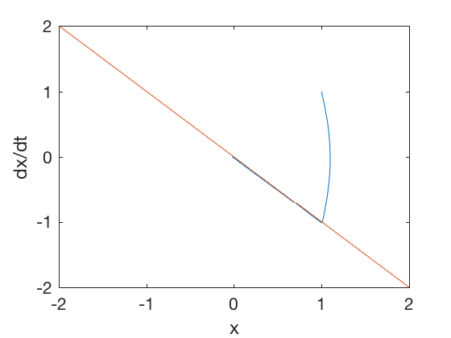

```matlab
plot(x(1,:),x(2,:))
hold on
plot([-2:.01:2],-lambda*[-2:.01:2])
xlabel('x')
ylabel('dx/dt')
```